# PARİTE: SIĞIR

### Et neden pahalı? 55 yılın, üç kıtanın ve 993 ayın cevabı

**Namık Akman · namikakman.dev** · Veri kesimi: Haziran/Temmuz 2026 · Kaynaklar: FRED/BLS · EC Agrifood · TÜİK/EVDS

Kasap vitrininin önünde durup etiketi iki kez okuyan herkes aynı soruyu soruyor: bu fiyat nereden geliyor? Ben o soruya cevap ararken fiyatın kendisine bakmayı bıraktım. Çünkü etin fiyatı tek başına bir şey söylemiyor; bir sığır, kesime gelene kadar aylarca yem yiyor ve o yemin de bir fiyatı var. Asıl hikâye bu ikisinin oranında: **bir birim et sattığınızda kaç birim yem alabiliyorsunuz?** Buna parite diyorum.

Bu rapor, üç kıtadan toplam 993 aylık veriyle — Amerika'da 1971'e, Türkiye'de 2010'a, Avrupa'da 2015'e uzanan serilerle — bu tek orandan okunabilecek her şeyi anlatıyor. Ve okuyunca görülüyor ki vitrindeki etiket keyfî bir rakam değil; ahırda yıllar önce verilmiş kararların, kesilen ineklerin ve biyolojinin acele etmeyen takviminin gecikmiş faturası. **Et neden pahalı sorusunun cevabı bugünde değil, üç yıl öncede saklı.**

> **Peki "yem" dediğimiz ne? Karnıyarık değil.** Bir besi sığırının tabağında dört kalem var: enerji (mısır, arpa), protein (soya ve ayçiçek küspesi), kaba yem (silaj, saman) ve premiks (vitamin-mineral). Bu rapordaki "yem" her seride biraz farklı ölçülüyor — ve bunu bilerek okumak gerek:
> - **ABD:** paydamız saf **mısır** ÜFE'si. Tek kalem, çünkü mısır Amerikan besi rasyonunun enerji omurgası ve 1971'e kadar kesintisiz aylık serisi olan tek tutarlı gösterge.
> - **AB:** **yemlik mısır** fiyatı (€/ton, EC 'feed maize'). Başta karma yem sanıyorduk; sağlamlık testi sırasında serinin birebir mısır olduğunu doğruladık ve etiketi düzelttik — rapor kendi hatasını da kayda geçirir.
> - **Türkiye:** TÜİK'in **"hazır hayvan yemleri"** ÜFE kalemi — yem fabrikası çıkışlı karma yemler (besi yemi, süt yemi).

> Dürüst dipnot: silaj ve saman gibi işletme içi kaba yem bu endekslerin dışında. Yani oranımız, "satın alınan yem" makasını ölçer — ki besicinin nakit akışını sıkan da tam olarak odur.

> **Peki bu elma elma mı?** Seviye olarak değil — ve bu raporda seviyeler zaten hiç yarıştırılmıyor. Ülkeler arası her karşılaştırma ya 2015=100 endeksiyle (değişimlerin yarışı) ya korelasyonla (ritmin yarışı) yapılıyor; mutlak karşılaştırma yalnız her ülkenin *kendi tarihine karşı* yüzdeliğidir. Bir incelik daha: ABD ve AB paydaları ham mısırdır (vahşi fiyatlanır); Türkiye paydası ise karma yem ÜFE'sidir — fabrika, hammadde şokunu stokla, kontratla ve reçete esnekliğiyle yumuşatır. Dolayısıyla TR serisinin görece sakin oynaklığının bir dilimi piyasa yapısından değil, bu ölçüm asimetrisinden gelir. ABD-AB karşılaştırması ise beklenenden de elma-elmadır: iki paydada da aynı tahıl var.

> **"Madem öyle, neden her yerde payda mısır değil?"** Çünkü cetveli eşitlemek, ölçtüğü şeyi eşitlemez. Rasyonlar bölgeye göre gerçekten farklı: ABD besisi mısır omurgalıdır — paydayı mısır seçmek orada tam isabettir. Ama Avrupa besisi arpa/buğday + küspe ağırlıklı beslenir, Türkiye'de de arpa ve küspe öne çıkar; mısırın rasyondaki payı ABD'dekinden düşüktür. "Her yerde mısır" dediğiniz anda cetvel aynı olur ama Türk besicisinin gerçek maliyetini artık ölçmüyor olursunuz: **karşılaştırılabilirlik kazanır, temsil gücü kaybedersiniz.** Biz tersini seçtik — her ülkede maliyeti en iyi temsil eden payda, karşılaştırma ise endeks ve korelasyonla. Yine de "peki hepsi mısır olsaydı sonuç değişir miydi?" sorusu meşru; cevabını raporun sonundaki sağlamlık testinde veriyoruz.

```
ABD: 666 ay (1971-01→2026-06) · AB: 129 ay · TR: 198 ay · toplam 993
```

## 1 · Hikâyenin özeti

```
──────────────────────────────────────────────────────────────────
ABD · bugün 2.44× (2026-06) · yüzdelik %99.8 · zirve 2.54 (2025-08) · dip 0.40 (1974-12)
AB  · bugün 2.82× (2026-07) · yüzdelik %88.3 · zirve 3.51 (2026-02) · dip 1.42 (2022-06)
TR  · bugün 1.31× (2026-06) · yüzdelik %92.9 · zirve 1.40 (2024-04) · dip 0.70 (2021-12)
──────────────────────────────────────────────────────────────────
ABD onyıl ortalamaları: 1970'ler 0.80 → 1980'ler 1.00 → 1990'ler 1.07 → 2000'ler 1.22 → 2010'ler 1.10 → 2020'ler 1.34
Yıllık değişim korelasyonları: ABD–AB 0.88 · AB–TR 0.68 · ABD–TR 0.58
──────────────────────────────────────────────────────────────────
MESAJ: Yem belirler — yem pahalanınca sürü küçülür; sürü küçülünce et, her kıtada pahalanır.
```

## 2 · ABD: bir besicinin 55 yılı

Bugün o besici hâlâ hayattaysa, ekranında 2,44 yazıyor ve 666 ayın yalnızca ikisinde bundan yükseğini görmüş. Elli beş yılın ortalaması 1,08, medyanı 1,05; onyıl ortalamaları 1970'lerin 0,80'inden 2020'lerin 1,34'üne tırmanmış. **Bir ömür boyunca sarkacın iki ucunu da görmüş; hiç bu kadar tepede durmamıştı.**

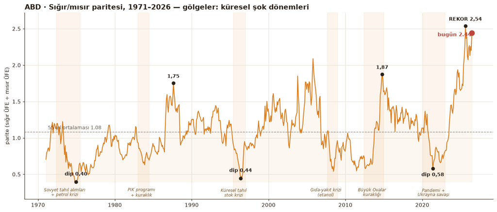

*Aşağıda aynı serinin rejim görünümü: beş yıllık bant hem yukarı kayıyor hem genişliyor — seviye ile birlikte belirsizlik de büyüyor.*

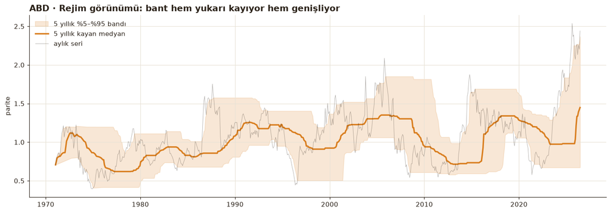

```
Kayan medyan: 1980'de 0.75 → 2000'de 0.92 → bugün 1.45
```

## 3 · Döngü laboratuvarı: dört dip, tek film

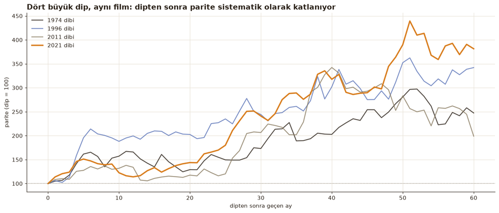

```
1974 dibi: 60 ayda ×3.0 (zirveye 52 ayda)
1996 dibi: 60 ayda ×3.6 (zirveye 51 ayda)
2011 dibi: 60 ayda ×3.4 (zirveye 40 ayda)
2021 dibi: 60 ayda ×4.4 (zirveye 51 ayda)
```

Dört dibi alıp üst üste koyduğumuzda — 1974, 1996, 2011, 2021, her birinde dip anını 100 sayıp sonraki 60 ayı izleyerek — ortaya çıkan şey rahatsız edici derecede düzenli: 1974 dibi 52. ayda üç katına, 1996 dibi 51. ayda 3,6 katına, 2011 dibi 40. ayda 3,4 katına, 2021 dibi 51. ayda 4,4 katına çıkmış. Dört farklı onyıl, dört farklı başkan, dört farklı kriz — aynı eğri.

**Tarih tekerrür etmiyor ama kafiyeli; ve bu kafiyeyi yazan Merkez Bankası değil, ineğin kendisi.** Yem pahalanınca üretici zarar eder ve damızlığını kesime gönderir; sürü küçülür. Ama kesilen ineğin yerine yenisi bir kararname ile gelmez: düvenin buzağısının kesim ağırlığına ulaşması yaklaşık üç yıl sürer. O üç yıllık biyolojik gecikme, dipten zirveye giden 40-52 aylık yolun neden hep aynı uzunlukta olduğunu açıklıyor. Faiz döngüsü hızlanabilir, yavaşlayabilir; gebelik süresi pazarlık kabul etmez.

## 4 · 55 yıl tek karede

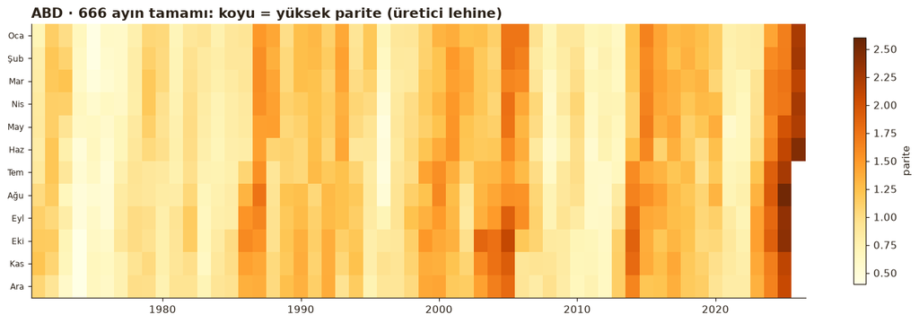

[output not shown]

## 5 · Avrupa'nın yastığı, Türkiye'nin faturası

Avrupa aynı hikâyeyi yastıklı bir odada yaşıyor. AB paritesinin ortalaması 2,24; Haziran 2022'deki 1,42'lik dipten Şubat 2026'daki 3,51'lik rekora uzanan yol, yön olarak Amerika'yla birebir aynı ama genlik olarak değil — dip-zirve oranı 2,5 kat, ABD'nin 4,4 katına kıyasla belirgin biçimde dar. Payda iki kıtada da aynı tahıl (mısır) olduğuna göre, bu yumuşaklığın kaynağı pay tarafında: CAP destekleri ve sözleşmeli üretim, Avrupa karkas fiyatını Amerikan sığır ÜFE'sinden çok daha az oynak kılıyor — süspansiyon yemde değil, ette. (Bir bölümü de dönem etkisi: AB serisi 2015'te başlıyor, 1974 ve 1996 tipi uçları hiç görmedi.)

[figure not shown]

## 6 · Üç kıta, tek nabız

Üç seriyi yan yana koyunca en çarpıcı rakam bir fiyat değil, bir korelasyon: ABD ile AB'nin on iki aylık değişimleri arasında 0,88. Bu, Iowa'daki bir mısır tarlasında olan bitenin, birkaç çeyrek içinde Bavyera'daki bir ahırın hesap defterine yazılması demek. Türkiye de bu hikâyenin dışında değil — AB ile 0,68, ABD ile 0,58 korelasyon — ama sinyali kur katmanından geçerek, kırılarak ve bazen şiddetlenerek alıyor; 2021 dibi bunun kanıtı. 2015'i 100 kabul eden ortak endeksle bugün ABD 162'de, AB 123'te, Türkiye 120'de: Amerika kendi tarihinden en çok kopan, Türkiye ile Avrupa ise şaşırtıcı biçimde yakın seyreden taraflar. **Küresel yem piyasası tek bir nabız atıyor; Konya'daki ahır, o nabzı döviz kuru üzerinden, biraz gecikmeli ve biraz sertleşmiş hâlde dinliyor.**

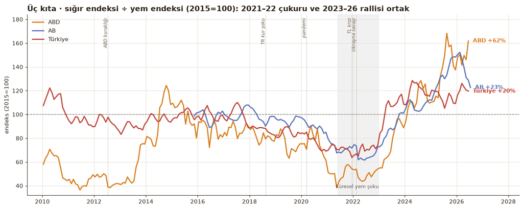

*Aşağıdaki saçılım, ABD ile AB'nin yıllık değişimlerini yıl yıl eşliyor — noktaların çizgiye bu kadar yakın durması, 0,88'lik korelasyonun kendisi.*

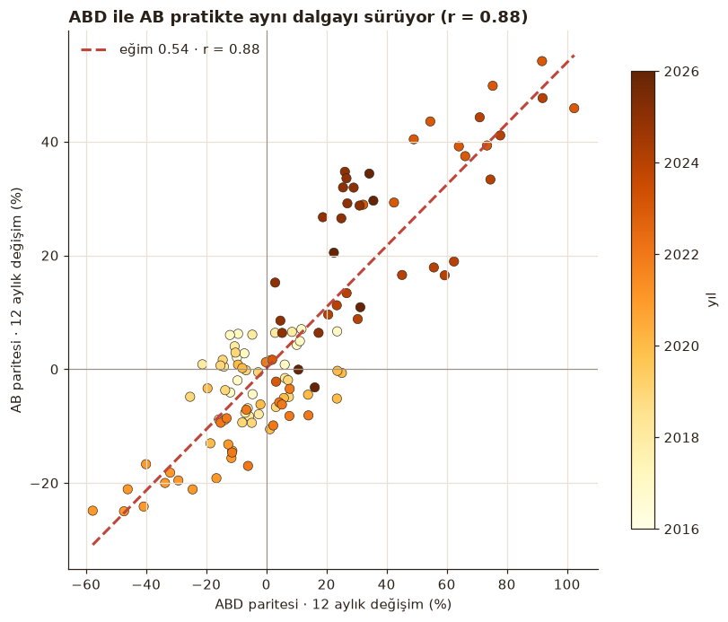

```
ABD–TR korelasyonu 0.58, AB–TR 0.68: Türkiye küresel dalga + kur bileşkesi.
```

## 7 · Şoklar aynı takvimde mi?

Buraya kadar "üç kıta aynı hikâyeyi yaşıyor" dedim; şimdi saatleri karşılaştıralım. Yıllık değişimleri ay ay kaydırıp eşleştirince çıkan tablo şu: **ABD ile AB tam eşzamanlı** — en yüksek korelasyon (0,88) sıfır ay gecikmede. Okyanusun iki yakası arasında saat farkı yok, çünkü ikisi de aynı anda aynı emtia fiyat ekranına bakıyor.

**Türkiye'nin saati ise birkaç ay ileri.** TR'nin değişimleri, ABD'ninkilerle en güçlü eşleşmeyi TR 4 ay öndeyken, AB'ninkilerle 3 ay öndeyken yakalıyor. Bu tuhaf görünebilir — küçük pazar büyüğü nasıl önceler? Cevap kurda: ithal girdili yem, döviz hareketini **anında** fiyatına yazar; küresel dalga Türkiye'ye çoğu kez "kur üzerinden erken ve sertleşmiş" gelir. 2018 ve 2021 kur şokları, küresel serilerde karşılığı sonradan görülen erken sarsıntılardır.

Tek tek olaylara inince sıralama daha da öğretici. 2020-22 şokunun dipleri: **ABD Mayıs 2021 → Türkiye Aralık 2021 → AB Haziran 2022.** Sonraki rallinin zirveleri: **Türkiye Nisan 2024 → ABD Ağustos 2025 → AB Şubat 2026.** İki turda da değişmeyen tek şey Avrupa'nın hep en sonda gelmesi — CAP süspansiyonu sadece genliği değil, takvimi de yumuşatıyor. Kriz Atlantik'te başlıyor, Ankara'da kurla sertleşiyor, Brüksel'e en son ve en yumuşak hâliyle ulaşıyor.

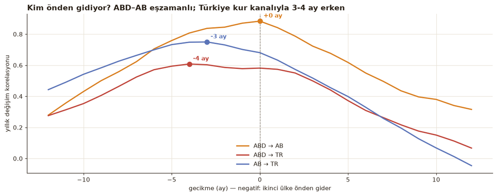

```
Dipler: ABD 2021-05 → TR 2021-12 → AB 2022-06  |  Zirveler: TR 2024-04 → ABD 2025-08 → AB 2026-02
```

## 8 · Peki besici nerede olmalı? — Üç coğrafyanın karnesi

Bu raporu en çok besicinin okuyacağını biliyorum; o yüzden soruyu onun sorduğu gibi soralım: **bu işi yapmak için hangi coğrafya avantajlı?** Verinin cevabı, "en yüksek parite nerede" değil — çünkü seriler farklı birimlerle kurulu ve seviyeler kıyaslanmaz. Kıyaslanabilir olan şey, her besicinin kendi tarihine karşı yaşadığı hayat: makasın oynaklığı, kötü dönemin uzunluğu ve bugünkü konum.

**Avrupa "az kazan, rahat uyu" coğrafyası.** Dip-zirve genliği (×2,5) Amerika'nın neredeyse yarısı; en kötü yıllık düşüş -%25'te kalmış, ortalama-altı en uzun dönem 45 ayla üçünün en kısası. Ortak Tarım Politikası destekleri ve çeşitlenmiş yem sepeti, şokları emen bir süspansiyon. Bedeli de belli: o süspansiyon zirveleri de yumuşatıyor — Avrupa besicisi Amerikalının gördüğü uçları hiç görmüyor, iki yönde de.

**Türkiye'nin derdi oynaklık değil, süre.** Şaşırtıcı ama veri böyle söylüyor: TR'nin yıllık değişim oynaklığı (%16) üçünün en düşüğü. Türk besicisinin sınavı sivri şoklar değil, **uzun basınç**: ortalamanın altında geçen en uzun dönem 64 ay — 2018'de başlayıp beş yılı aşan o erozyon. Üstüne, bu orana hiç yansımayan iki yerli katman biner: kur (yem girdisinin ithalat yoğunluğu) ve yüksek enflasyon ortamında işletme sermayesi finansmanı. Telafi dönemleri ise sert ve tatlı: bugün 1,31 ile serinin %92'lik diliminde.

Hüküm — veri kadarıyla ve dürüstçe: **"nerede"den önce "ne zaman" sorusu geliyor;** üç pazarda da kazandıran şey coğrafya değil, döngünün neresinde durduğunu bilmek. Ama karakter testi olarak okursan: sarkaca mideniz dayanıyorsa ABD, istikrar arıyorsanız AB, iki katmanlı oyunu — küresel döngü artı kur — aynı anda okuyabiliyorsanız Türkiye. Bir de şu not: arazi, işçilik, destek ödemeleri ve finansman maliyeti bu veri setinin dışında; nihai işletme kararı bu karneyle değil, bu karne **artı** o kalemlerle verilir.

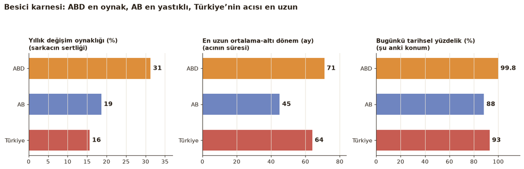

```
En kötü yıl: ABD -%58 · AB -%25 · TR -%20  |  Dip→zirve genlik: ABD ×4,4 · AB ×2,5
```

## 9 · Yetiştiricinin P&L'i: 100 liralık satışın anatomisi

Buraya kadar hep orandan konuştuk; şimdi o oranı bir besicinin **kâr-zarar tablosuna** çevirelim. Elimizdeki veri yalnız et ve yem fiyatı; dana alımı, işçilik ve finansman serilerimiz yok. O yüzden dürüst bir **stilize model** kuruyoruz — varsayımlar masada:

> **Model (100 birim satış geliri üzerinden):** Dana/besi materyali alımı **45** ve diğer giderler (işçilik, enerji, veterinerlik, bakım) **15** sabit tutulur — sektör literatürünün tipik aralıklarıdır. **Yem kalemi ise canlıdır:** her bölgenin kendi uzun-dönem ortalama paritesinde 35 olacak şekilde kalibre edilir ve parite değiştikçe ters orantıyla değişir (parite ikiye katlanırsa yem yükü yarıya iner). Finansman maliyeti modelde yok — Türkiye gerçeğinde bu, tabloyu daha da sıkıştıran ek bir kalemdir.

Bu basit makine, üç bölgenin yaşadığını tek bakışta anlatıyor. **Amerikan besicisinin 1974 dibinde** yem kalemi tek başına 94'e fırlıyor: 100 liralık satışın maliyeti 155 lira — her satış, cebinden 55 lira götürüyor. ABD'deki sürü tasfiyelerinin neden bu kadar vahşi olduğunun cevabı bu satırda. **Türk besicisinin 2021 dibi** daha "ılımlı" görünüyor: 100 satışta 12 zarar. Ama asıl yıkım oranda değil sürede — o zarar bandında beş yıl yaşandı ve modelin saymadığı finansman maliyeti eklenince tablo daha da kararıyor. **Bugün ise üç bölgede de yeşil:** ABD 100'de ~25, AB ve Türkiye ~12'şer kâr yazıyor — ki bu, dana ve diğer giderler sabitken görülebilecek en tatlı dönemlerden biri.

Bir dürüstlük notu daha: gerçekte dana fiyatı da döngüseldir — dip dönemde dana ucuzlar (zarar bir miktar yumuşar), zirvede pahalanır (kâr törpülenir). Yani sabit-45 varsayımı uçları olduğundan biraz sivri gösterir; yönü değil, dozu etkiler.

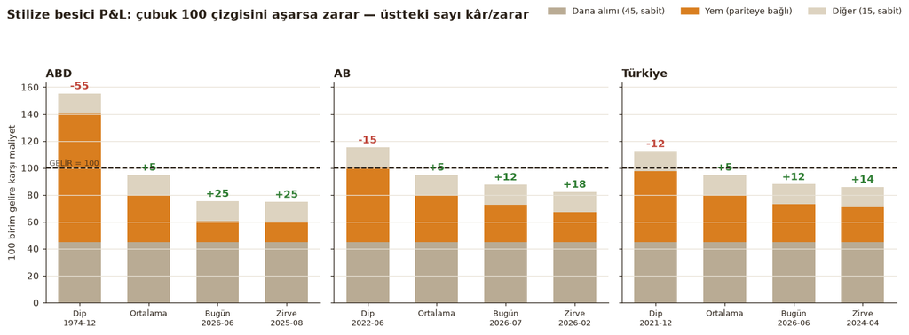

```
ABD: dip kârı -55 · bugün +25 · zirve +25  (100 gelir başına)
AB: dip kârı -15 · bugün +12 · zirve +18  (100 gelir başına)
Türkiye: dip kârı -12 · bugün +12 · zirve +14  (100 gelir başına)
```

## 10 · Sağlamlık testi: ya payda her yerde mısır olsaydı?

**Türkiye'de test yapılamıyor — ve bu da başlı başına bir bulgu.** TCMB EVDS kataloğunun tamamını taradık: 611 veri grubu, binlerce seri. Aylık bir mısır *fiyat* serisi yok; katalogda "Mısır" adına ne varsa ülke olan Mısır çıktı — turizm geliri, Mısır Lirası kuru, IMF makro serileri. Türk besicisinin yem enflasyonunu izlemek isteyen bir analistin elindeki en iyi resmî aylık araç, bizim de kullandığımız "hazır hayvan yemleri" ÜFE'sidir. Dolayısıyla ölçüm asimetrisi uyarımız (ham tahıl ↔ fabrika endeksi) artık tek bir sınırda yaşıyor: ABD/AB ile Türkiye arasında. Yorumlarımızı da buna göre kalibre ettik.

## 11 · Sonuç: geç fazın okuması

Verinin bugünkü mesajı net: **döngünün geç fazındayız.** Zirveler üç coğrafyada da geride — ABD Ağustos 2025'te 2,54'ü, AB Şubat 2026'da 3,51'i, Türkiye Nisan 2024'te 1,40'ı gördü — ve geçmiş döngülerde zirveden ortalamaya dönüş iki ila dört yıl sürdü. Yüksek kâr, kesimden alıkonan her düveyle sürüyü yeniden büyütüyor; mekanizmanın normalleşme kolu çoktan çalışmaya başladı.

**Üreticiye** söyleyeceğim şu: bugünkü 2,44'ler, 1,31'ler tarihin istisnası, kalıcı gelir varsayımı değil — borçlanmayı bu zirveye değil, 1,08'lik ortalamaya göre kurun. **Tüketiciye:** vitrindeki fiyat üç yıl önceki kesim kararlarının faturası; rahatlama gelecek ama takvimi ineğin biyolojisi yazıyor, sabır ayla değil yılla ölçülüyor. **Politika yapıcıya:** müdahalenin en pahalı anı dip anıdır — 2018-22'de beş yıl 0,85'te ezilen üretici korunsaydı, 2024'ün 1,40'lık zirvesi bu kadar sivri olmayabilirdi.

Çünkü et fiyatı kimsenin tercihi değil; ahırda başlayan, tarladan geçen ve üç yıl gecikmeyle vitrine ulaşan bir maliyet hikâyesi. **Hikâyeyi ucuzlatmanın tek yolu, onu baştan okumak.**

*Veri, kod ve film: namikakman.dev · [GitHub](https://github.com/namikakmandev/namikakmandev.github.io) — FRED/BLS · EC Agrifood · TÜİK/EVDS. PDF rapor: `notes/parite-sigir-veri-raporu.pdf`.*